# Part II - Presentation Showing Major Factors That Affect Borrower APR

## by IBRAHIM SALMAN

## Investigation Overview

In this representation, I'll be showing you the major factors that affect borrower APR. These factors include:

1. Credit Grade
2. Income Range

## Dataset Overview

The Prosper Loan dataset contains 113,937 loans with 83 variables (2 new variables on `YearlyIncomeEstimate`(derived from `StatedMonthlyIncome`) and `IncomeRange`(derived from `YearlyIncomeEstimate`) to better stratify the data set) on each loan, including loan amount, borrower APR, borrower rate (or interest rate), current loan status, borrower income, and many others.

## Distribution of Borrower APR

The Borrower APR data has values ranging from 0.006530 to 0.512290. The distribution increases steadily from 0.006530 (min) then peaks at the 0.15 - 0.225 range with other smaller peaks towards the right making it multimodal in nature.

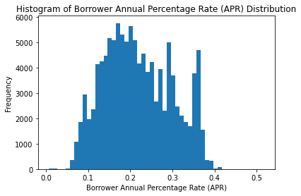

## Distribution of Credit Grade

The distribution increases steadily from the AA grade and peaks at the C grade then a steady decline from the C grade to the lowest level HR.

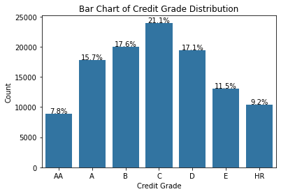

## Income Range Distribution

From the visualization below, it can be concluded that the most common borrowers have income ranges of USD25,000-49,999 and USD50,000-74,999.

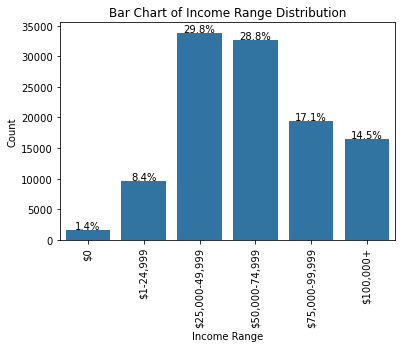

## Borrower APR Vs. Credit Grade

This visualization shows that generally, the higher the credit grade level, the lower the Borrower APR.

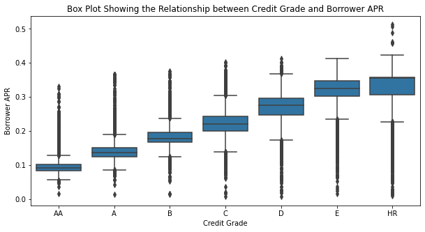

## Borrower APR Vs. Income Range

This visualization shows that starting from the `$1-24,999` range, the Borrower APR generally decreases with increasing income range.  
The `$0` range doesn't follow the trend probably because borrowers that are meant to be in other income ranges didn't fill in their StatedMonthlyIncome correctly.

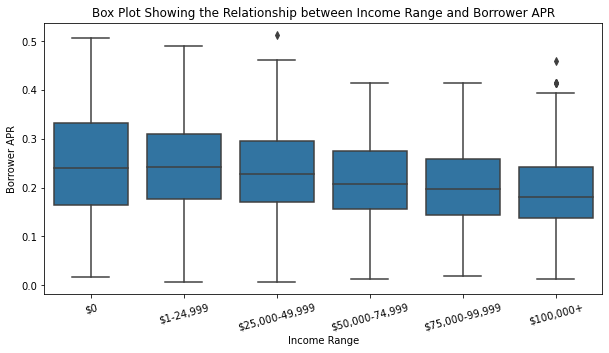

## Borrower APR Vs. Income Range by Credit Grade

When the relationship between Borrower APR and Income Range is filtered by credit grade, it shows the Borrower APR in each credit grade are very similar.

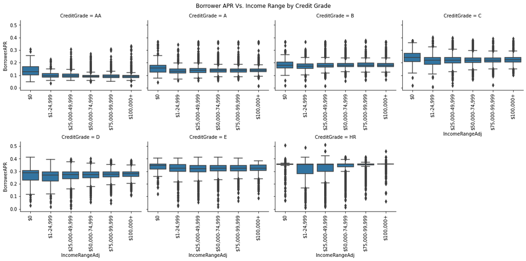

## Borrower APR Vs. Credit Grade by Income Range

There is a strong relationship between credit grade and borrower APR. The visual below shows how the credit grade A borrowers always have a low Borrower APR regardless of the income range.

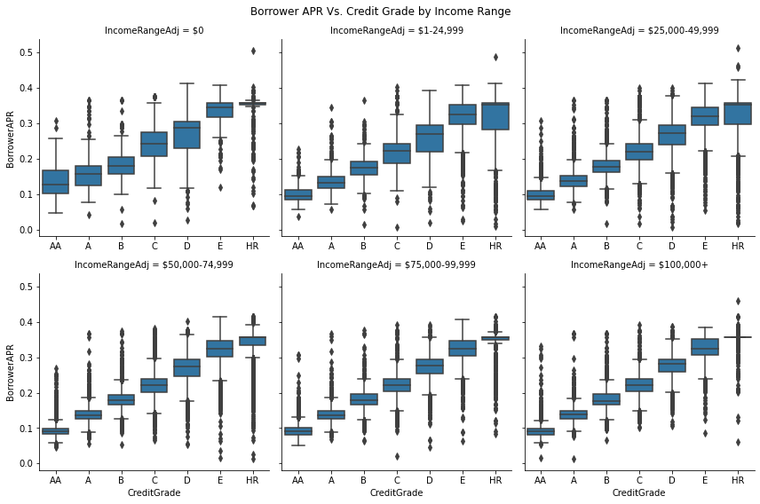